# Practical Machine Learning Project

Gracy

22 December 2017

### OVERVIEW

This to predict the manner in which 6 participants performed some exercise as described below. This is the “classe” variable in the training set. The machine learning algorithm described here is applied to the 20 test cases available in the test data and the predictions are submitted in appropriate format to the Course Project Prediction Quiz for automated grading. Using devices such as Jawbone Up, Nike FuelBand, and Fitbit it is now possible to collect a large amount of data about personal activity relatively inexpensively. These type of devices are part of the quantified self movement - a group of enthusiasts who take measurements about themselves regularly to improve their health, to find patterns in their behavior, or because they are tech geeks. One thing that people regularly do is quantify how much of a particular activity they do, but they rarely quantify how well they do it. In this project, your goal will be to use data from accelerometers on the belt, forearm, arm, and dumbell of 6 participants. They were asked to perform barbell lifts correctly and incorrectly in 5 different ways. More information is available from the website here: http://groupware.les.inf.puc-rio.br/har (see the section on the Weight Lifting Exercise Dataset).

### Environment Setting and Read files into R

```r
rm(list=ls())
```

```r
#Set the working environment. Switch to required directory
setwd("C:/Users/Gracy/Coursera - Data Science Specialization/Course 8 - Practical Machine Learning/Week 4")
```

```r
fileUrl.train <- "https://d396qusza40orc.cloudfront.net/predmachlearn/pml-training.csv"
fileUrl.test <- "https://d396qusza40orc.cloudfront.net/predmachlearn/pml-testing.csv"
```

```r
#download.file(fileUrl.train,destfile = "pml-training.csv")
#download.file(fileUrl.test,destfile = "pml-testing.csv")
```

```r
library(caret)
library(parallel)
library(doParallel)
library(dplyr)
```

```r
training <- read.csv("pml-training.csv")
testing <- read.csv("pml-testing.csv")
dim(testing)
```

```
## [1]  20 160
```

```r
dim(training)
```

```
## [1] 19622   160
```

### Clean up the Data

```r
# remove variables with Nearly Zero Variance
NZV <- nearZeroVar(training)
training <- training[, -NZV]
testing  <- testing[, -NZV]
dim(training)
```

```
## [1] 19622   100
```

```r
dim(testing)
```

```
## [1]  20 100
```

```r
# remove variables that are mostly NA
AllNA    <- sapply(training, function(x) mean(is.na(x))) > 0.95
training <- training[, AllNA==FALSE]
testing  <- testing[, AllNA==FALSE]
dim(training)
```

```
## [1] 19622    59
```

```r
dim(testing)
```

```
## [1] 20 59
```

```r
# remove identification only variables (columns 1 to 5)
training <- training[, -(1:5)]
testing  <- testing[, -(1:5)]
dim(training)
```

```
## [1] 19622    54
```

```r
dim(testing)
```

```
## [1] 20 54
```

### Making an initial fit with all predictors for feature selection

To improve processing time of the multiple executions of the train() function, caret supports the parallel processing capabilities of the parallel package. Parallel processing in caret can be accomplished with the parallel and doParallel packages.

```r
#Method: Random Forest
cluster <- makeCluster(detectCores() - 1) # convention to leave 1 core for OS
registerDoParallel(cluster)

fitControl <- trainControl(method = "cv", number = 5, allowParallel = TRUE)

fit <- train(classe ~ ., method="rf",data=training,trControl = fitControl)

stopCluster(cluster)
registerDoSEQ()
```

### Feature Selection using Variable Importance method

The varImp process chooses the best 20 predictors and those are the columns selected for testing and training data.

```r
var.imp <- varImp(fit)
var.imp
```

```
## rf variable importance
##
##   only 20 most important variables shown (out of 53)
##
##                      Overall
## num_window           100.000
## roll_belt             63.274
## pitch_forearm         39.252
## yaw_belt              30.506
## magnet_dumbbell_z     28.253
## pitch_belt            27.909
## magnet_dumbbell_y     27.693
## roll_forearm          22.104
## accel_dumbbell_y      12.909
## magnet_dumbbell_x     10.314
## accel_forearm_x        9.668
## roll_dumbbell          9.600
## accel_belt_z           8.762
## total_accel_dumbbell   8.407
## accel_dumbbell_z       7.656
## magnet_belt_z          6.767
## magnet_forearm_z       6.500
## magnet_belt_y          6.389
## magnet_belt_x          5.261
## roll_arm               4.819
```

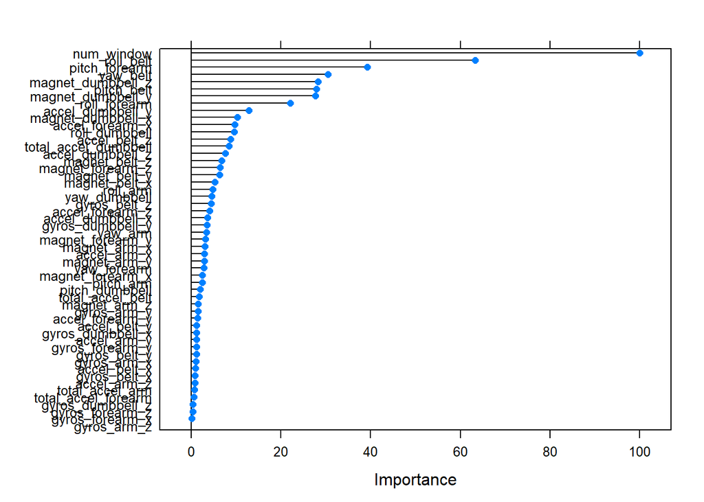

```r
var.imp.cols.train <- c("num_window","roll_belt", "pitch_forearm","yaw_belt",     "magnet_dumbbell_z","pitch_belt",      "magnet_dumbbell_y",
"roll_forearm",     "accel_dumbbell_y", "magnet_dumbbell_x","accel_forearm_x",  "roll_dumbbell",
"accel_belt_z",     "total_accel_dumbbell","accel_dumbbell_z", "magnet_belt_z",          "magnet_forearm_z",
"magnet_belt_y",          "magnet_belt_x",          "roll_arm" , "classe")
var.imp.cols.test <- c("num_window","roll_belt", "pitch_forearm","yaw_belt",     "magnet_dumbbell_z","pitch_belt",      "magnet_dumbbell_y",
"roll_forearm",     "accel_dumbbell_y", "magnet_dumbbell_x","accel_forearm_x",  "roll_dumbbell",
"accel_belt_z",     "total_accel_dumbbell","accel_dumbbell_z", "magnet_belt_z",          "magnet_forearm_z",
"magnet_belt_y",          "magnet_belt_x",          "roll_arm" )
training <- training[,c(var.imp.cols.train)]
testing <- testing[,c(var.imp.cols.test)]

plot(var.imp)
```